# Bank Marketing - EDA

Ming Ming Zhang

## 1. Packages

```r
library(rminer)
library(ggplot2)
```

## 2. Exploratory Data Analysis (EDA)

We will analyze the data by summarizing its main characteristics using visual methods.

The dataset contains $41,188$ examples, $20$ features and a response variable labled by `y` indicating if the client subscribes a bank term deposit (“yes” or “no”), ordered by date (from May 2008 to November 2010).

```r
D = read.table("bank-additional-full.csv", header=TRUE, sep=";")
str(D)
```

```
'data.frame':   41188 obs. of  21 variables:
 $ age           : int  56 57 37 40 56 45 59 41 24 25 ...
 $ job           : Factor w/ 12 levels "admin.","blue-collar",..: 4 8 8 1 8 8 1 2 10 8 ...
 $ marital       : Factor w/ 4 levels "divorced","married",..: 2 2 2 2 2 2 2 2 3 3 ...
 $ education     : Factor w/ 8 levels "basic.4y","basic.6y",..: 1 4 4 2 4 3 6 8 6 4 ...
 $ default       : Factor w/ 3 levels "no","unknown",..: 1 2 1 1 1 2 1 2 1 1 ...
 $ housing       : Factor w/ 3 levels "no","unknown",..: 1 1 3 1 1 1 1 1 3 3 ...
 $ loan          : Factor w/ 3 levels "no","unknown",..: 1 1 1 1 3 1 1 1 1 1 ...
 $ contact       : Factor w/ 2 levels "cellular","telephone": 2 2 2 2 2 2 2 2 2 2 ...
 $ month         : Factor w/ 10 levels "apr","aug","dec",..: 7 7 7 7 7 7 7 7 7 7 ...
 $ day_of_week   : Factor w/ 5 levels "fri","mon","thu",..: 2 2 2 2 2 2 2 2 2 2 ...
 $ duration      : int  261 149 226 151 307 198 139 217 380 50 ...
 $ campaign      : int  1 1 1 1 1 1 1 1 1 1 ...
 $ pdays         : int  999 999 999 999 999 999 999 999 999 999 ...
 $ previous      : int  0 0 0 0 0 0 0 0 0 0 ...
 $ poutcome      : Factor w/ 3 levels "failure","nonexistent",..: 2 2 2 2 2 2 2 2 2 2 ...
 $ emp.var.rate  : num  1.1 1.1 1.1 1.1 1.1 1.1 1.1 1.1 1.1 1.1 ...
 $ cons.price.idx: num  94 94 94 94 94 ...
 $ cons.conf.idx : num  -36.4 -36.4 -36.4 -36.4 -36.4 -36.4 -36.4 -36.4 -36.4 -36.4 ...
 $ euribor3m     : num  4.86 4.86 4.86 4.86 4.86 ...
 $ nr.employed   : num  5191 5191 5191 5191 5191 ...
 $ y             : Factor w/ 2 levels "no","yes": 1 1 1 1 1 1 1 1 1 1 ...
```

The data is imbalanced.

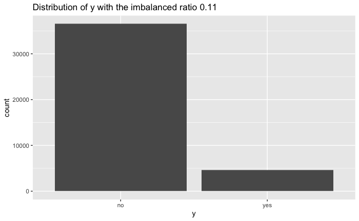

```r
ggplot(D, aes(y)) + geom_bar() +
  ggtitle(paste("Distribution of y with the imbalanced ratio", round(sum(table(D$y)[2])/sum(table(D$y)), 2)))
```

The following function is to calculate the ratio of clients who subscribe the product for a categorical feature within each level.

```r
findRatio = function(featureName) {
  mat = matrix(0, nrow = length(unique(D[,featureName])), ncol = 4)
  for (x in unique(D[,featureName])) {
    mat[which(unique(D[,featureName])==x),] = c(x, sum(D$y=="yes" & D[,featureName]==x), sum(D$y=="no" & D[,featureName]==x), sum(D$y=="yes" & D[,featureName]==x) / sum(D[,featureName]==x))
    }
  df = data.frame(mat, stringsAsFactors = F)
  colnames(df) = c(featureName, "yes", "no", "ratio")
  df$yes = as.numeric(df$yes)
  df$no = as.numeric(df$no)
  df$ratio = as.numeric(df$ratio)
  df$ratio = round(df$ratio, 2)
  df
  }
```

### 2.1. Bank Client Information

#### 2.1.1. `age`

The feature `age` is the age of client (numeric). It has no relationship with `y`.

```r
summary(D$age)
```

```
   Min. 1st Qu.  Median    Mean 3rd Qu.    Max.
  17.00   32.00   38.00   40.02   47.00   98.00
```

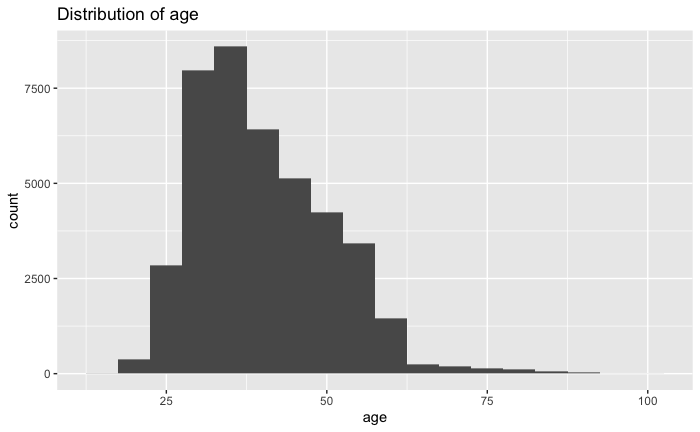

```r
ggplot(D, aes(age)) + geom_histogram(binwidth = 5) + ggtitle("Distribution of age")
```

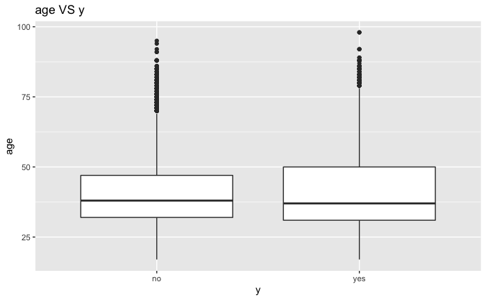

```r
ggplot(D, aes(x=y, y=age)) + geom_boxplot() + ggtitle("age VS y")
```

#### 2.1.2. `job`

The feature `job` is type of job (categorical). For subscribed ratio, the top 3 categories are student, retired and unemployed, while the last 3 categories are entrepreneur, services and blue-collar. Since there are variations between subscribed ratio within each category, it has a relationship with `y`.

```r
table(D$job)
```

```
       admin.   blue-collar  entrepreneur     housemaid    management       retired self-employed      services       student
        10422          9254          1456          1060          2924          1720          1421          3969           875
   technician    unemployed       unknown
         6743          1014           330
```

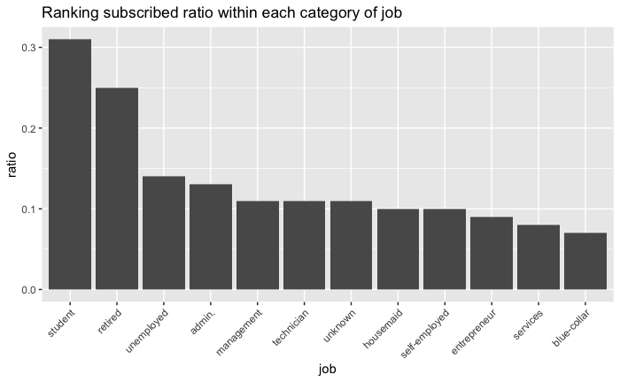

```r
jobRatio = findRatio("job")
ggplot(jobRatio, aes(x=reorder(job, -ratio), y=ratio)) + geom_bar(stat="identity") +
  theme(axis.text.x = element_text(angle=45, hjust=1)) +
  xlab("job") + ggtitle("Ranking subscribed ratio within each category of job")
```

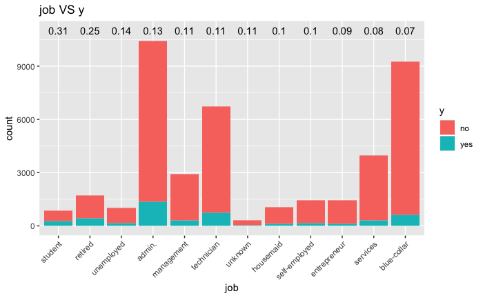

```r
ggplot(merge(D,jobRatio), aes(x=reorder(job,-ratio), fill=y)) + geom_bar() +
  theme(axis.text.x = element_text(angle=45, hjust=1)) +
  annotate("text", x = 1:12, y=11000, label = sort(jobRatio$ratio, decreasing = T)) +
  xlab("job") + ggtitle("job VS y")

ggsave(filename = "~/Downloads/bank-additional/fig1.png")
```

#### 2.1.3. `marital`

The feature `marital` is marital status (categorical). For subscribed ratio, the top 2 categories are unknown and single, while the last 2 categories are divorced and married. Note that there are only 80 clients with unknown marital status. Since there are variations between subscribed ratio within each category, it has a relationship with `y`.

```r
table(D$marital)
```

```
divorced  married   single  unknown
    4612    24928    11568       80
```

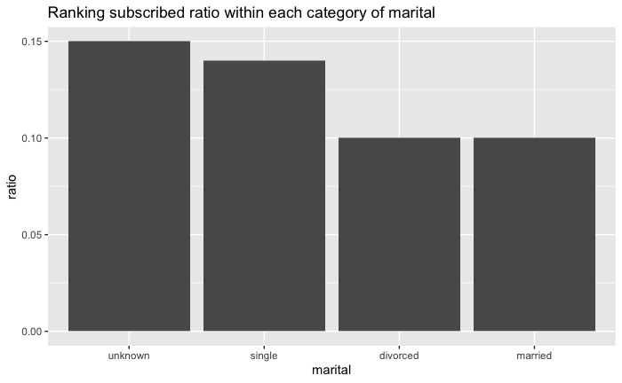

```r
maritalRatio = findRatio("marital")
ggplot(maritalRatio, aes(x=reorder(marital, -ratio), y=ratio)) + geom_bar(stat="identity") +
  #theme(axis.text.x = element_text(angle=45, hjust=1)) +
  xlab("marital") + ggtitle("Ranking subscribed ratio within each category of marital")
```

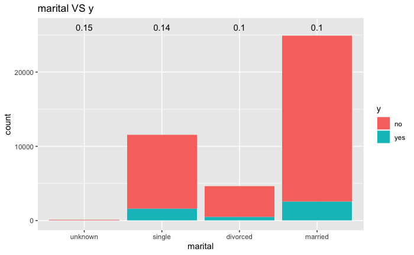

```r
ggplot(merge(D,maritalRatio), aes(x=reorder(marital,-ratio), fill=y)) + geom_bar() +
  #theme(axis.text.x = element_text(angle=45, hjust=1)) +
  annotate("text", x = 1:4, y=26000, label = sort(maritalRatio$ratio, decreasing = T)) +
  xlab("marital") + ggtitle("marital VS y")
```

#### 2.1.4. `education`

The feature `education` is education background for the client (categorical). For subscribed ratio, the top 3 categories are illiterate, unknown and university degree, while the last 3 categories are basic.4y, basic.6y and basic.9y. Note that there only 18 clients who are illiterate. Since there are variations between subscribed ratio within each category, it has a relationship with `y`.

```r
table(D$education)
```

```
           basic.4y            basic.6y            basic.9y         high.school          illiterate professional.course
               4176                2292                6045                9515                  18                5243
  university.degree             unknown
              12168                1731
```

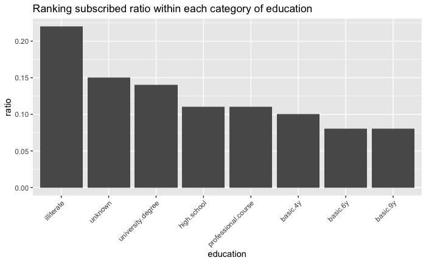

```r
eduRatio = findRatio("education")
ggplot(eduRatio, aes(x=reorder(education, -ratio), y=ratio)) + geom_bar(stat="identity") +
  theme(axis.text.x = element_text(angle=45, hjust=1)) +
  xlab("education") + ggtitle("Ranking subscribed ratio within each category of education")
```

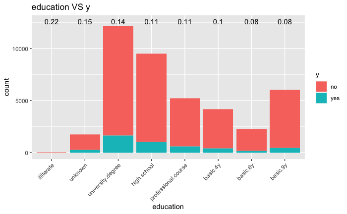

```r
ggplot(merge(D,eduRatio), aes(x=reorder(education,-ratio), fill=y)) + geom_bar() +
  theme(axis.text.x = element_text(angle=45, hjust=1)) +
  annotate("text", x = 1:8, y=12600, label = sort(eduRatio$ratio, decreasing = T)) +
  xlab("education") + ggtitle("education VS y")

ggsave(filename = "~/Downloads/bank-additional/fig2.png")
```

#### 2.1.5. `default`

The feature `default` indicates the client has credit in default or not (categorical). For subscribed ratio, the top category is no. Note that there only 3 clients who has default. Since there are variations between subscribed ratio within each category, it has a relationship with `y`.

```r
table(D$default)
```

```
     no unknown     yes
  32588    8597       3
```

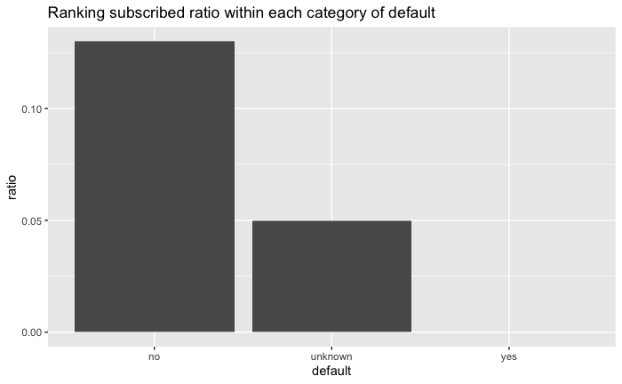

```r
defaultRatio = findRatio("default")
ggplot(defaultRatio, aes(x=reorder(default, -ratio), y=ratio)) + geom_bar(stat="identity") +
  #theme(axis.text.x = element_text(angle=45, hjust=1)) +
  xlab("default") + ggtitle("Ranking subscribed ratio within each category of default")
```

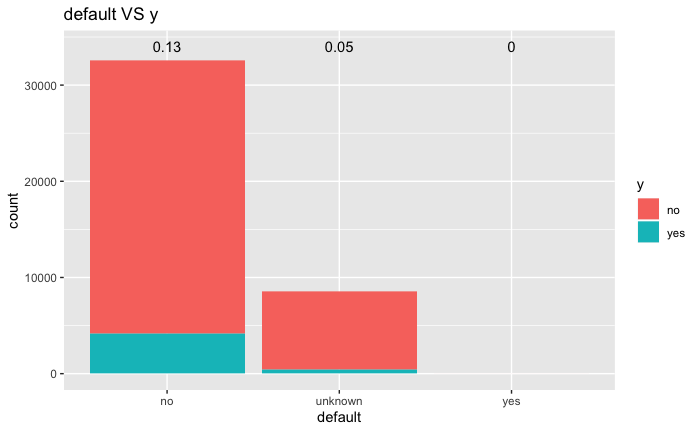

```r
ggplot(merge(D,defaultRatio), aes(x=reorder(default,-ratio), fill=y)) + geom_bar() +
  #theme(axis.text.x = element_text(angle=45, hjust=1)) +
  annotate("text", x = 1:3, y=34000, label = sort(defaultRatio$ratio, decreasing = T)) +
  xlab("default") + ggtitle("default VS y")
```

#### 2.1.6. `housing`

The feature `housing` indicates the client has housing loan or not (categorical). For subscribed ratio, the top category is yes, while no and unknown are about the same. Since there are not too much variations between subscribed ratio within each category, it has no strong relationship with `y`.

```r
table(D$housing)
```

```
     no unknown     yes
  18622     990   21576
```

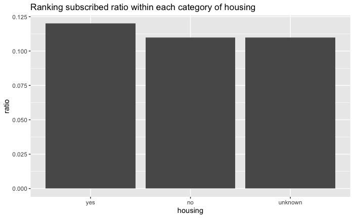

```r
housingRatio = findRatio("housing")
ggplot(housingRatio, aes(x=reorder(housing, -ratio), y=ratio)) + geom_bar(stat="identity") +
  #theme(axis.text.x = element_text(angle=45, hjust=1)) +
  xlab("housing") + ggtitle("Ranking subscribed ratio within each category of housing")
```

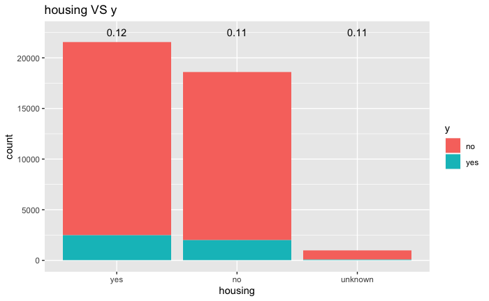

```r
ggplot(merge(D,housingRatio), aes(x=reorder(housing,-ratio), fill=y)) + geom_bar() +
  #theme(axis.text.x = element_text(angle=45, hjust=1)) +
  annotate("text", x = 1:3, y=22500, label = sort(housingRatio$ratio, decreasing = T)) +
  xlab("housing") + ggtitle("housing VS y")
```

#### 2.1.7. `loan`

```r
table(D$loan)
```

```
     no unknown     yes
  33950     990    6248
```

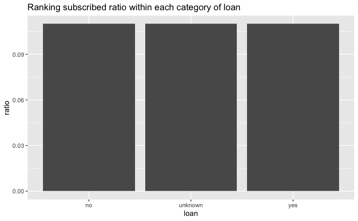

```r
loanRatio = findRatio("loan")
ggplot(loanRatio, aes(x=reorder(loan, -ratio), y=ratio)) + geom_bar(stat="identity") +
  #theme(axis.text.x = element_text(angle=45, hjust=1)) +
  xlab("loan") + ggtitle("Ranking subscribed ratio within each category of loan")
```

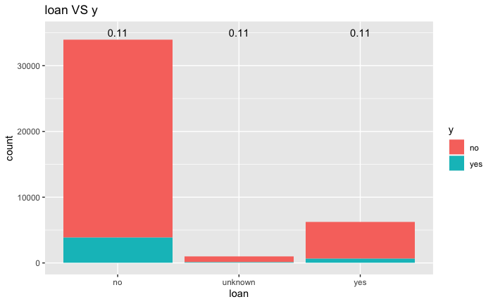

```r
ggplot(merge(D,loanRatio), aes(x=reorder(loan,-ratio), fill=y)) + geom_bar() +
  #theme(axis.text.x = element_text(angle=45, hjust=1)) +
  annotate("text", x = 1:3, y=35000, label = sort(loanRatio$ratio, decreasing = T)) +
  xlab("loan") + ggtitle("loan VS y")
```

### 2.2. Last Contact Information

#### 2.2.1. `contact`

The feature `contact` is contact communication type (categorical). For subscribed ratio, the top category is cellular, while the last catefory is telephone. Since there is variation between subscribed ratio within each category, it has a relationship with `y`.

```r
table(D$contact)
```

```
 cellular telephone
    26144     15044
```

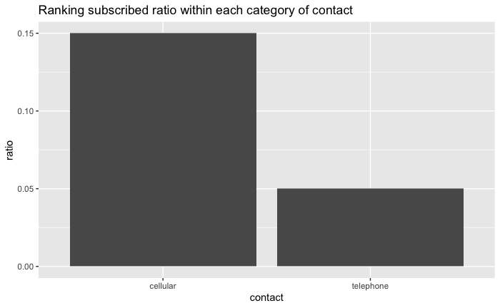

```r
contactRatio = findRatio("contact")
ggplot(contactRatio, aes(x=reorder(contact, -ratio), y=ratio)) + geom_bar(stat="identity") +
  #theme(axis.text.x = element_text(angle=45, hjust=1)) +
  xlab("contact") + ggtitle("Ranking subscribed ratio within each category of contact")
```

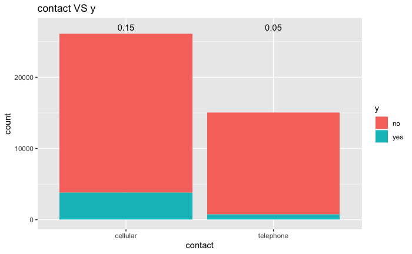

```r
ggplot(merge(D,contactRatio), aes(x=reorder(contact,-ratio), fill=y)) + geom_bar() +
  #theme(axis.text.x = element_text(angle=45, hjust=1)) +
  annotate("text", x = 1:2, y=27000, label = sort(contactRatio$ratio, decreasing = T)) +
  xlab("contact") + ggtitle("contact VS y")
```

#### 2.2.2. `month`

The feature `month` is last contact month of year (categorical). For subscribed ratio, the top 4 categories are march, december, september and october, while the last category is may. Since there are variations between subscribed ratio within each category, it has a relationship with `y`.

```r
table(D$month)
```

```
  apr   aug   dec   jul   jun   mar   may   nov   oct   sep
 2632  6178   182  7174  5318   546 13769  4101   718   570
```

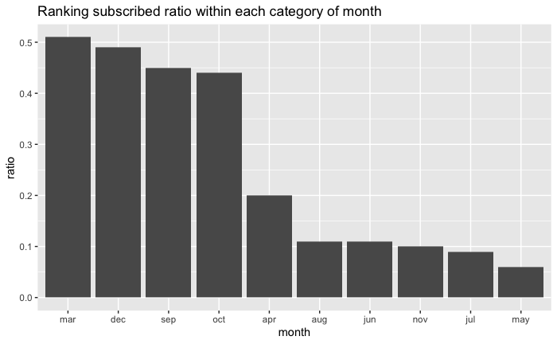

```r
monthRatio = findRatio("month")
ggplot(monthRatio, aes(x=reorder(month, -ratio), y=ratio)) + geom_bar(stat="identity") +
  #theme(axis.text.x = element_text(angle=45, hjust=1)) +
  xlab("month") + ggtitle("Ranking subscribed ratio within each category of month")
```

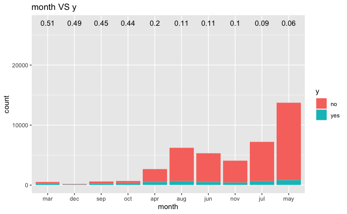

```r
ggplot(merge(D,monthRatio), aes(x=reorder(month,-ratio), fill=y)) + geom_bar() +
  #theme(axis.text.x = element_text(angle=45, hjust=1)) +
  annotate("text", x = 1:10, y=27000, label = sort(monthRatio$ratio, decreasing = T)) +
  xlab("month") + ggtitle("month VS y")

ggsave(filename = "~/Downloads/bank-additional/fig3.png")
```

#### 2.2.3. `day_of_week`

The feature `day_of_week` is last contact day of the week (categorical). For subscribed ratio, the top 3 categories are thursday, tuesday and wednesday, while the last category is monday. Since there are variations between subscribed ratio within each category, it has a relationship with `y`.

```r
table(D$day_of_week)
```

```
 fri  mon  thu  tue  wed
7827 8514 8623 8090 8134
```

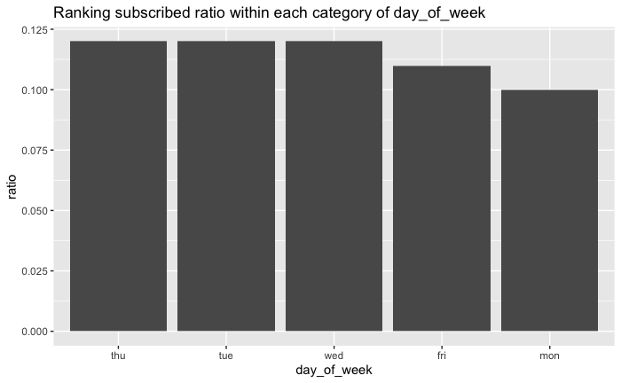

```r
dayRatio = findRatio("day_of_week")
ggplot(dayRatio, aes(x=reorder(day_of_week, -ratio), y=ratio)) + geom_bar(stat="identity") +
  #theme(axis.text.x = element_text(angle=45, hjust=1)) +
  xlab("day_of_week") + ggtitle("Ranking subscribed ratio within each category of day_of_week")
```

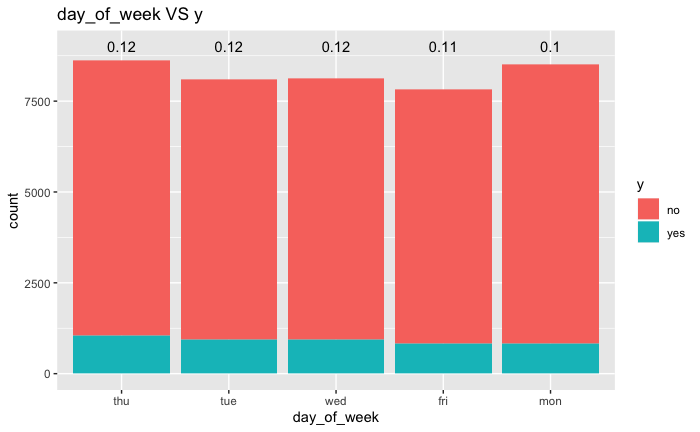

```r
ggplot(merge(D,dayRatio), aes(x=reorder(day_of_week,-ratio), fill=y)) + geom_bar() +
  #theme(axis.text.x = element_text(angle=45, hjust=1)) +
  annotate("text", x = 1:5, y=9000, label = sort(dayRatio$ratio, decreasing = T)) +
  xlab("day_of_week") + ggtitle("day_of_week VS y")
```

#### 2.2.4. `duration`

The feature `duration` is last contact duration, in seconds (numeric). The distribution is skewed. For subscribed ratio, if duration is 0 then no subscriber; otherwise, longer duration is higher than shorter duration. It has a strong relationship with `y`.

```r
summary(D$duration)
```

```
   Min. 1st Qu.  Median    Mean 3rd Qu.    Max.
    0.0   102.0   180.0   258.3   319.0  4918.0
```

```r
summary(D$duration[D$y=="yes"])
```

```
   Min. 1st Qu.  Median    Mean 3rd Qu.    Max.
   37.0   253.0   449.0   553.2   741.2  4199.0
```

```r
summary(D$duration[D$y=="no"])
```

```
   Min. 1st Qu.  Median    Mean 3rd Qu.    Max.
    0.0    95.0   163.5   220.8   279.0  4918.0
```

```r
m0 = median(D$duration[D$y=="no"])
m1 = median(D$duration[D$y=="yes"])

durationRatio = c(sum(D$y=="yes" & D$duration<=m0)/sum(D$duration<=m0), sum(D$y=="yes" & D$duration>=m1)/sum(D$duration>=m1))
durationRatio
```

```
[1] 0.02257167 0.39069846
```

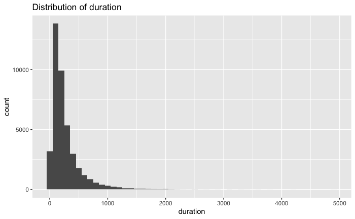

```r
ggplot(D, aes(duration)) + geom_histogram(binwidth = 100) + ggtitle("Distribution of duration")
```

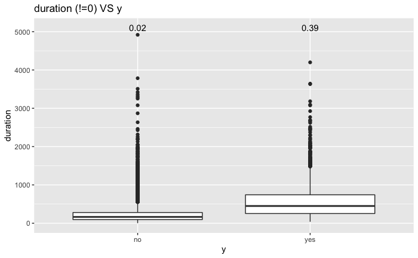

```r
ggplot(D[D$duration!=0,], aes(x=y, y=duration)) + geom_boxplot() + ggtitle("duration (!=0) VS y") +
  annotate("text", x = 1:2, y=5100, label = round(durationRatio,2))
ggsave(filename = "~/Downloads/bank-additional/fig4.png")
```

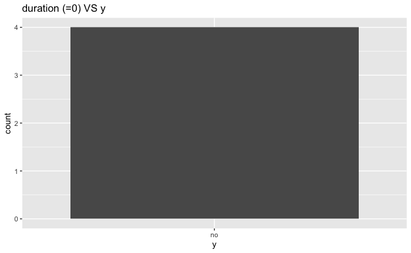

```r
ggplot(D[D$duration==0,], aes(x=y)) + geom_bar() + ggtitle("duration (=0) VS y")
```

### 2.3. History Information

#### 2.3.1. `campaign`

The feature `campaign` is number of contacts performed during this campaign and for this client (numeric). The distribution is skewed. It has no strong relationship with `y`.

```r
summary(D$campaign)
```

```
   Min. 1st Qu.  Median    Mean 3rd Qu.    Max.
  1.000   1.000   2.000   2.568   3.000  56.000
```

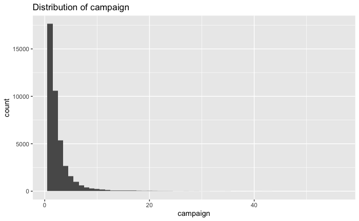

```r
ggplot(D, aes(campaign)) + geom_histogram(binwidth = 1) + ggtitle("Distribution of campaign")
```

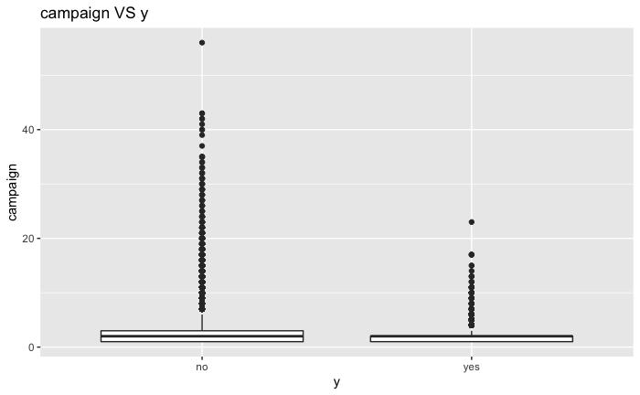

```r
ggplot(D, aes(x=y, y=campaign)) + geom_boxplot() + ggtitle("campaign VS y")
```

#### 2.3.2. `pdays`

The feature `pdays` is number of days that passed by after the client was last contacted from a previous campaign (numeric; 999 means client was not previously contacted). The distribution is skewed. It has no strong relationship with `y`.

```r
summary(D$pdays)
```

```
   Min. 1st Qu.  Median    Mean 3rd Qu.    Max.
    0.0   999.0   999.0   962.5   999.0   999.0
```

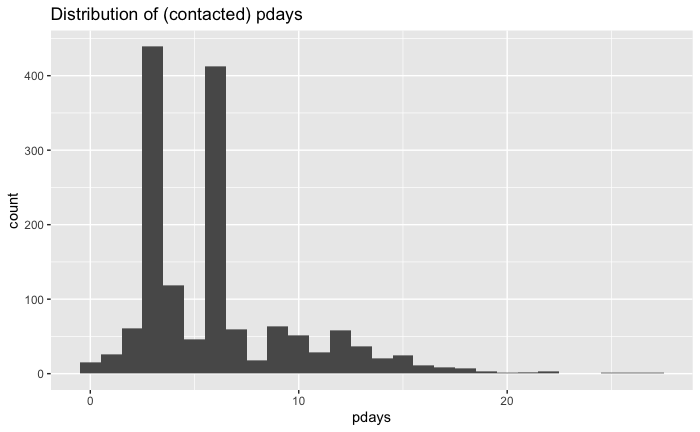

```r
ggplot(D[D$pdays!=999,], aes(pdays)) + geom_histogram(binwidth = 1) + ggtitle("Distribution of (contacted) pdays")
```

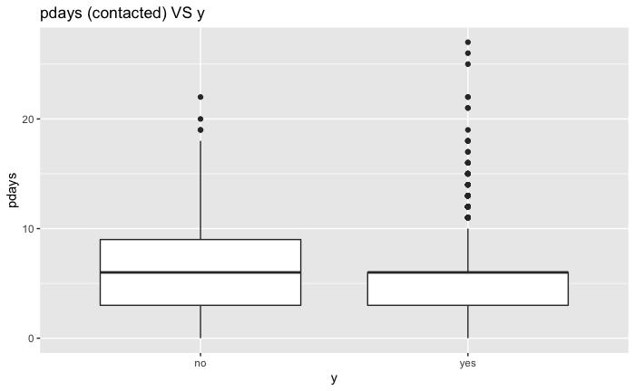

```r
ggplot(D[D$pdays!=999,], aes(x=y, y=pdays)) + geom_boxplot() + ggtitle("pdays (contacted) VS y")
```

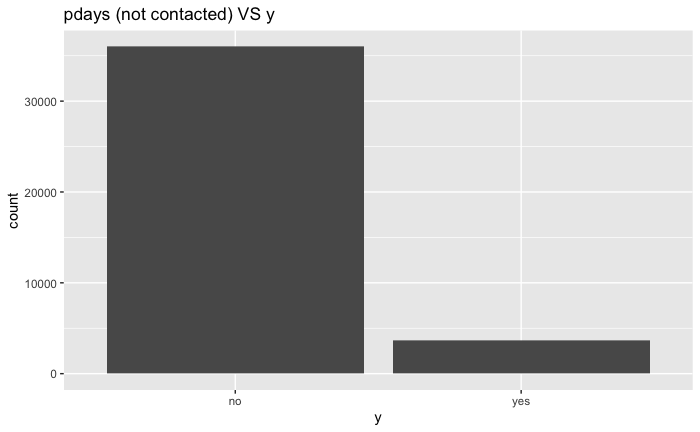

```r
ggplot(D[D$pdays==999,], aes(x=y)) + geom_bar() + ggtitle("pdays (not contacted) VS y")
```